# Density Plots

Albert Y. Kim  
Wednesday 2015/04/01

### Density

In probability theory, a probability density function (PDF), or density of a continuous random variable, is a function that describes the relative likelihood for this random variable to take on a given value.

The area under the curve of a density is 1 i.e. 100%.

### Density

[figure not shown]

### One-Dimensional Case

Say you have observations \( (x_1, \ldots, x_n) \) of some continuous random variable. Example the Old Faithful geyser in Yellowstone National Park eruption times

```
  [1] 3.600 1.800 3.333 2.283 4.533
  [6] 2.883 4.700 3.600 1.950 4.350
 [11] 1.833 3.917 4.200 1.750 4.700
 [16] 2.167 1.750 4.800 1.600 4.250
 [21] 1.800 1.750 3.450 3.067 4.533
 [26] 3.600 1.967 4.083 3.850 4.433
 [31] 4.300 4.467 3.367 4.033 3.833
 [36] 2.017 1.867 4.833 1.833 4.783
 [41] 4.350 1.883 4.567 1.750 4.533
 [46] 3.317 3.833 2.100 4.633 2.000
 [51] 4.800 4.716 1.833 4.833 1.733
 [56] 4.883 3.717 1.667 4.567 4.317
 [61] 2.233 4.500 1.750 4.800 1.817
 [66] 4.400 4.167 4.700 2.067 4.700
 [71] 4.033 1.967 4.500 4.000 1.983
```

[output cut: 40 more lines]

### One-Dimensional Case

The simplest approximation to \( (x_1, \ldots, x_n) \)'s density is a histogram where on the y-axis we are not representing **counts**, but rather **proportions**. i.e. the sum of the area of the boxes is 1.

Density is the more general term for proportion.

### One-Dimensional Case

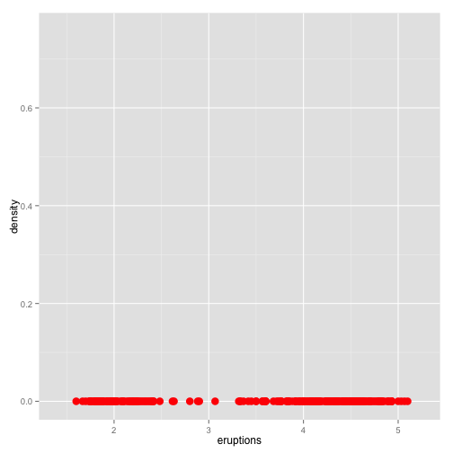

### One-Dimensional Case

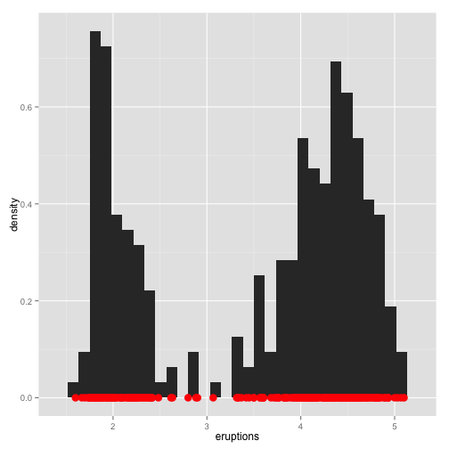

### Density Curve in Red

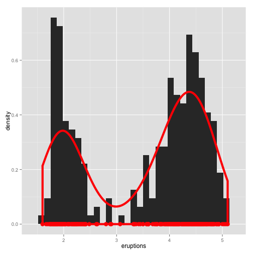

### Two Dimensions

For two dimensions, each observation is a pair of points \( (x_i, y_i) \) for \( i=1, \ldots, n \). Now

- Our bins are actually boxes, not intervals
- A histogram for these would require a third dimension sticking out of the page to show the height corresponding to each box

### Two Dimensions

So rather we have **concentric circles** indicate density. We use the `geom_density2d()` command on the front of your cheatsheet under two variables.

### Example

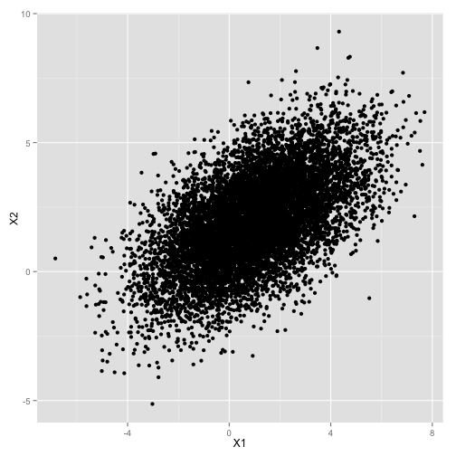

### Setting alpha Parameter in geom_point()

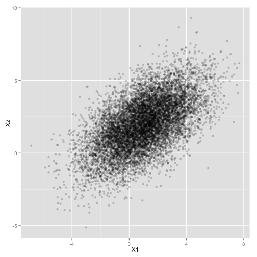

### Concentric Circles Representing Densities

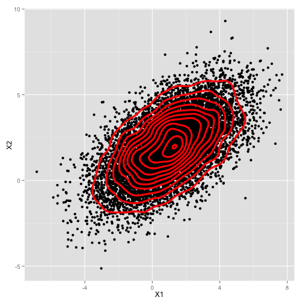